# Panduan Penggunaan klbfederated

Analisis federated kejadian luar biasa untuk dinas kesehatan

Penulis

Ahmad Watsiq Maula

Diterbitkan

31 Agustus 2026

# Tentang panduan ini

Panduan ini menuntun petugas dinas kesehatan memakai package **klbfederated** dari nol, mulai dari memasang R sampai mengisi seluruh isian pada aplikasi, menjalankan analisis, menyusun laporan, dan mengirim ringkasan ke tingkat provinsi.

Package ini terdiri dari dua aplikasi yang saling terhubung:

| Aplikasi | Dipakai oleh | Isinya |
| --- | --- | --- |
| **Node kabupaten atau kota** | Petugas surveilans kabupaten atau kota | Data investigasi individu, analisis, penyusunan laporan |
| **Dashboard provinsi** | Dinas kesehatan provinsi | Ringkasan agregat seluruh KLB di wilayah provinsi |

Prinsip yang dipegang sistem ini: **data individu tidak pernah meninggalkan node kabupaten atau kota**. Yang dikirim ke provinsi hanya angka agregat, tanpa satu pun baris responden.

```
KoboToolbox  ──>  Node kabupaten atau kota  ──agregat──>  Dashboard provinsi
                   (SQLite lokal, analisis R,              (tanpa data individu)
                    laporan Word)
```

Seluruh analisis mengikuti Pedoman Penyelidikan dan Penanggulangan KLB Penyakit Menular dan Keracunan Pangan, Kementerian Kesehatan, Edisi Revisi III Tahun 2020.

**CatatanData contoh**

Seluruh tangkapan layar pada panduan ini memakai dua investigasi contoh yang disertakan package, yaitu KLB keracunan pangan pada hajatan dan KLB pertusis di satu kalurahan. Kedua data itu **fiktif** dan hanya untuk latihan.

# 1 Persiapan

## 1.1 Memasang R

R adalah perangkat lunak gratis yang menjadi mesin perhitungan package ini.

1. Buka https://cran.r-project.org.
2. Pilih sistem operasi Anda:
   - **Windows**: klik *Download R for Windows*, lalu *base*, lalu *Download R x.y.z for Windows*.
   - **macOS**: klik *Download R for macOS*, lalu pilih berkas `.pkg` yang sesuai prosesor Anda (Apple silicon atau Intel).
   - **Linux**: ikuti petunjuk distribusi masing masing.
3. Jalankan berkas pemasang, ikuti sampai selesai dengan pilihan bawaan.

Versi minimum yang dibutuhkan adalah **R 4.1**. Versi terbaru lebih disarankan.

## 1.2 Memasang RStudio atau Positron

Anda dapat memakai R langsung, tetapi bekerja akan jauh lebih nyaman memakai salah satu editor berikut. Keduanya gratis.

- **RStudio Desktop**: https://posit.co/download/rstudio-desktop
- **Positron**: https://positron.posit.co

## 1.3 Memasang package klbfederated

Buka R atau editor pilihan Anda, lalu jalankan dua baris berikut pada konsol.

```r
install.packages("remotes")
remotes::install_github("wmaula/klbfederated")
```

Pemasangan pertama mengunduh sekitar dua puluh package pendukung, seperti shiny, ggplot2, dan officer. Pada koneksi biasa proses ini memakan waktu lima sampai lima belas menit. Bila muncul pertanyaan `Do you want to install from sources the package which needs compilation?`, jawab `no` agar lebih cepat.

**TipMemperbarui ke versi terbaru**

Setiap kali ada perbaikan, jalankan perintah yang sama dengan tambahan `force = TRUE`, lalu tutup dan buka kembali sesi R Anda.

```r
remotes::install_github("wmaula/klbfederated", force = TRUE)
```

## 1.4 Memeriksa hasil pemasangan

Jalankan perintah berikut. Bila keluar ringkasan analisis, berarti pemasangan berhasil.

```r
library(klbfederated)

contoh <- contoh_keracunan_pangan(n = 60)
hasil <- analisis_klb(
  contoh$data, contoh$pemetaan, contoh$konfigurasi,
  jenis = "keracunan_pangan"
)
hasil
```

```
Hasil analisis KLB
  Populasi berisiko   : 240
  Diinvestigasi       : 60
  Kasus               : 43 (attack rate 71,7 persen)
  Meninggal           : 0 (CFR 0,0 persen)
  Masa inkubasi       : 1,00 sampai 7,82 jam, rata-rata 3,65 jam
  Kurva epidemik      : common source, interval 0,91 jam
  Paparan bermakna    :
    Rendang daging sapi: RR 27,77 (95% CI 1,82 sampai 424,23), p <1e-04
  Peringatan          :
    - Matriks kovarians robust pada model multivariabel mendekati singular karena sebagian pengamatan memiliki leverage mendekati satu. Selang kepercayaan pada model ini dapat terlalu sempit atau terlalu lebar, sehingga hasil bivariat lebih dapat diandalkan.
    - Sebagian tabel 2x2 memiliki sel bernilai nol sehingga estimasi memakai koreksi 0,5 (Haldane-Anscombe). Tafsirkan selang kepercayaan dengan hati-hati.
    - Attack rate dihitung dengan penyebut responden terinvestigasi (60). Populasi berisiko yang diestimasi 240 orang dilaporkan terpisah.
```

## 1.5 Kebutuhan sistem

| Kebutuhan | Keterangan |
| --- | --- |
| R 4.1 atau lebih baru | Wajib |
| Peramban modern | Chrome, Edge, atau Safari terbaru |
| Koneksi internet | Diperlukan saat menarik data KoboToolbox, mengirim ke provinsi, dan mengunduh model bahasa. Analisis sendiri berjalan luring |
| WebGPU pada peramban | Hanya bila ingin memakai model bahasa untuk memperhalus laporan |
| Ruang penyimpanan | Sekitar 500 MB untuk R dan package, ditambah 1 sampai 3 GB bila memakai model bahasa |

# 2 Menjalankan aplikasi

## 2.1 Node kabupaten atau kota

```r
library(klbfederated)
jalankan_node(port = 4001, data_contoh = TRUE)
```

Argumen `data_contoh = TRUE` memuat dua investigasi latihan bila basis data masih kosong. Untuk pemakaian sungguhan, hilangkan argumen itu.

Peramban akan terbuka pada alamat http://127.0.0.1:4001. Bila tidak terbuka sendiri, ketik alamat itu di peramban Anda.

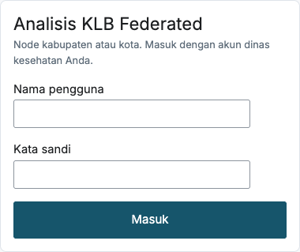

Halaman masuk node kabupaten atau kota

## 2.2 Dashboard provinsi

Dashboard provinsi dijalankan pada **sesi R yang terpisah**, biasanya di komputer atau server dinas kesehatan provinsi.

```r
library(klbfederated)
jalankan_dashboard_provinsi(port = 4102, port_ingest = 4002)
```

Perintah ini membuka dua hal sekaligus, yaitu antarmuka dashboard pada port 4102 dan pintu penerimaan laporan agregat pada port 4002. Port penerimaan itulah yang dituju oleh node kabupaten.

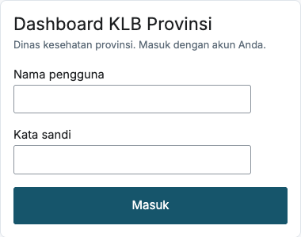

Halaman masuk dashboard provinsi

## 2.3 Akun awal dan peran pengguna

Saat pertama kali dijalankan, aplikasi membuat akun `admin` dengan kata sandi `admin123`. Bila Anda memuat data contoh, dua akun tambahan ikut dibuat.

| Pengguna | Kata sandi awal | Peran | Yang dapat dilakukan |
| --- | --- | --- | --- |
| `admin` | `admin123` | Admin | Semua, termasuk pengaturan node dan manajemen pengguna |
| `analis` | `analis123` | Analis | Membuat investigasi, menarik data, analisis, laporan, pengiriman |
| `viewer` | `viewer123` | Viewer | Hanya melihat |

**PeringatanGanti kata sandi bawaan**

Kata sandi bawaan hanya untuk memulai. Segera ganti melalui menu **Pengaturan** setelah login pertama. Aplikasi akan mengingatkan Anda.

Untuk menetapkan kata sandi admin sendiri sebelum basis data pertama kali dibuat, atur variabel lingkungan berikut.

```r
Sys.setenv(KLB_ADMIN_USER = "surveilans", KLB_ADMIN_PASSWORD = "kata-sandi-yang-kuat")
```

## 2.4 Tempat data disimpan

Seluruh data tersimpan pada berkas SQLite di komputer Anda, bawaannya di `~/.klbfederated`. Untuk memindahkannya, misalnya ke folder yang rutin dicadangkan, atur sebelum menjalankan aplikasi.

```r
Sys.setenv(KLB_DATA_DIR = "D:/data-klb")
```

# 3 Pengaturan awal

Buka tab **Pengaturan**. Bagian ini biasanya cukup diisi sekali.

## 3.1 Menghubungkan ke KoboToolbox

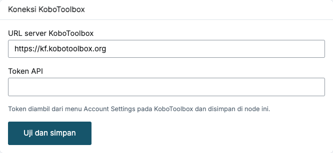

Isian koneksi KoboToolbox

Cara memperoleh token API KoboToolbox:

1. Masuk ke akun KoboToolbox Anda, biasanya di https://kf.kobotoolbox.org.
2. Klik foto profil di pojok kanan atas, pilih **Account Settings**.
3. Buka bagian **Security**, lalu salin **API key** yang tampil.

Tempelkan token itu pada isian **Token API**, pastikan **URL server** sesuai dengan server tempat proyek Anda berada, lalu klik **Uji dan simpan**. Bila berhasil, muncul pemberitahuan berisi nama akun KoboToolbox Anda.

**PentingToken adalah kunci akses**

Token setara dengan kata sandi untuk data Anda. Token disimpan pada basis data node dan hanya dipakai proses R di komputer itu. Jangan membagikannya lewat surel atau grup percakapan.

## 3.2 Identitas node dan tujuan pengiriman

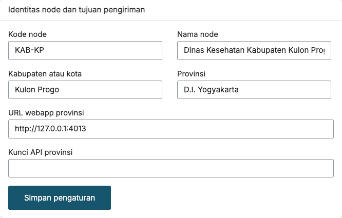

Identitas node dan alamat webapp provinsi

| Isian | Contoh | Keterangan |
| --- | --- | --- |
| Kode node | `KAB-KULONPROGO` | Pengenal singkat, disepakati dengan provinsi |
| Nama node | `Dinas Kesehatan Kabupaten Kulon Progo` | Tampil pada dashboard provinsi |
| Kabupaten atau kota | `Kulon Progo` | Dipakai pada rekapitulasi provinsi |
| Provinsi | `D.I. Yogyakarta` | Dipakai pada rekapitulasi provinsi |
| URL webapp provinsi | `http://10.10.10.5:4002` | Alamat pintu penerimaan di provinsi |
| Kunci API provinsi | diberikan provinsi | Lihat bagian berikut |

Kunci API diterbitkan oleh dinas kesehatan provinsi melalui dashboard provinsi, tab **Node dan pengguna**. Kunci hanya ditampilkan satu kali saat dibuat.

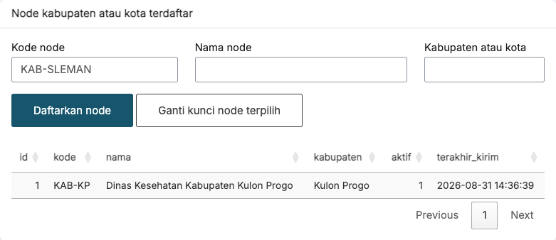

Pendaftaran node di dashboard provinsi

## 3.3 Menambah pengguna

Peran admin dapat menambah akun untuk petugas lain.

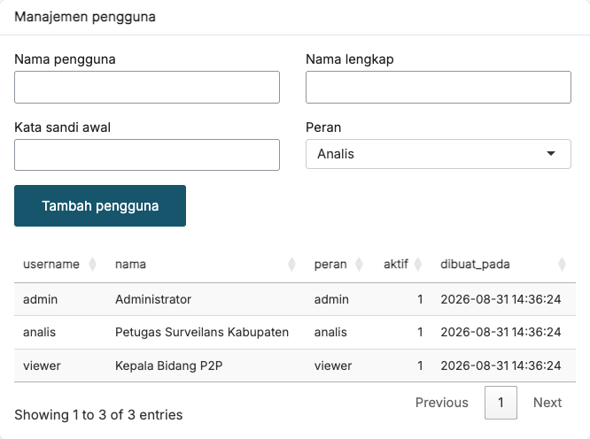

Manajemen pengguna

Berikan peran **analis** untuk petugas yang mengerjakan investigasi, dan **viewer** untuk pimpinan yang cukup melihat hasil.

# 4 Membuat investigasi

Satu investigasi KLB berpasangan dengan satu proyek KoboToolbox. Buka tab **Investigasi**.

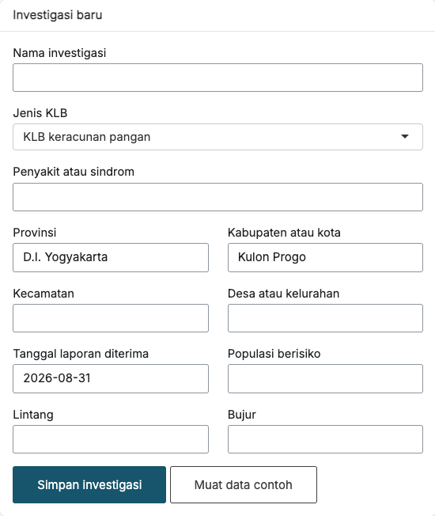

Formulir investigasi baru

| Isian | Wajib | Penjelasan |
| --- | --- | --- |
| Nama investigasi | Ya | Sebaiknya memuat jenis KLB, tempat, dan tahun |
| Jenis KLB | Ya | Menentukan variabel apa saja yang wajib dipetakan nanti |
| Penyakit atau sindrom | Tidak | Misalnya keracunan pangan, pertusis, difteri |
| Provinsi dan kabupaten | Ya | Terisi otomatis dari pengaturan node |
| Kecamatan dan desa | Tidak | Memperjelas lokasi pada dashboard provinsi |
| Tanggal laporan diterima | Tidak | Dipakai pada kronologi laporan |
| Populasi berisiko | Tidak | Estimasi jumlah orang terpapar, dipakai sebagai pembanding |
| Lintang dan bujur | Tidak | Menempatkan KLB pada peta provinsi |

Pilihan **Jenis KLB** menentukan variabel wajib pada tahap pemetaan.

| Jenis KLB | Cocok untuk | Variabel wajib tambahan |
| --- | --- | --- |
| Keracunan pangan | Keracunan makanan pada hajatan, kantin, katering | Waktu paparan, lokasi paparan, jenis pangan |
| Penyakit menular | Diare, hepatitis A, penyakit menular lain | Klasifikasi kasus, faktor risiko non pangan |
| PD3I | Campak, pertusis, difteri | Klasifikasi kasus, status imunisasi |

Setelah tersimpan, investigasi muncul pada tabel. **Klik satu baris** untuk mulai bekerja. Baris terpilih ditandai dan keterangannya tampil di bawah tabel.

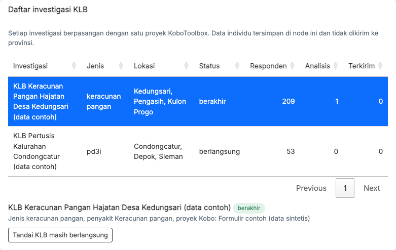

Daftar investigasi dan investigasi yang sedang dipilih

**PeringatanSelalu pilih investigasi lebih dahulu**

Seluruh tab lain bekerja pada investigasi yang sedang dipilih. Bila belum ada yang dipilih, tombol pada tab lain tidak akan berjalan dan aplikasi akan mengingatkan Anda.

# 5 Menarik data dari KoboToolbox

Buka tab **Data KoboToolbox**. Panel di bagian atas menunjukkan lima langkah beserta tandanya, sehingga Anda selalu tahu di mana posisi Anda.

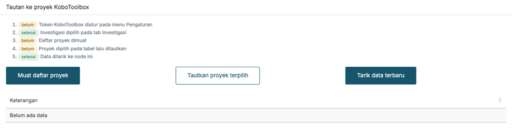

Panel langkah penautan dan penarikan data

Urutannya empat langkah, dan **tidak boleh dilompati**:

1. Pastikan satu investigasi sudah dipilih pada tab Investigasi.
2. Klik **Muat daftar proyek**. Seluruh proyek survei pada akun KoboToolbox Anda akan tampil.
3. **Klik satu baris proyek** pada tabel, lalu klik **Tautkan proyek terpilih**. Aplikasi membaca definisi formulir, termasuk memekarkan pertanyaan pilihan ganda menjadi kolom biner.
4. Klik **Tarik data terbaru**. Seluruh submission diunduh dan disimpan pada node ini.

Setelah data masuk, pratinjau tampil di bawah.

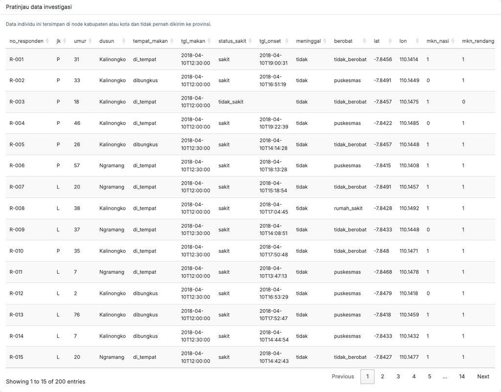

Pratinjau data investigasi yang tersimpan di node

**CatatanMenarik ulang data aman dilakukan**

Penarikan berikutnya memperbarui baris yang sudah ada dan menambahkan yang baru, berdasarkan nomor submission. Data tidak akan berlipat.

Bila muncul pesan galat, lihat Bagian 12 pada bagian pemecahan masalah.

# 6 Pemetaan variabel

Tahap ini menerjemahkan nama kolom pada formulir Kobo menjadi peran yang dikenali analisis. Buka tab **Pemetaan variabel**.

## 6.1 Membaca status kelengkapan

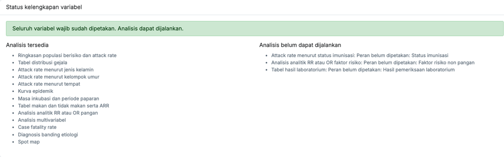

Status kelengkapan variabel

Panel ini memberi tahu tiga hal: variabel wajib yang belum dipetakan, catatan yang perlu diperhatikan, serta daftar analisis yang sudah dapat dijalankan dan yang masih terkunci. **Analisis baru dapat dijalankan setelah seluruh variabel wajib terpetakan.**

## 6.2 Mengisi peran variabel

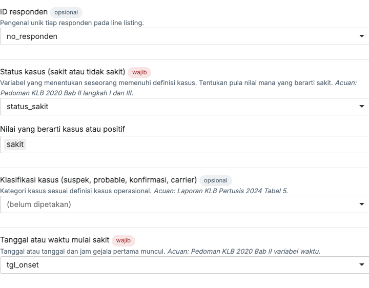

Contoh pengisian peran variabel

Setiap peran memiliki penjelasan singkat dan rujukan pedomannya. Cara mengisi:

- **Peran tunggal**, misalnya umur atau jenis kelamin, dipilih satu kolom dari daftar.
- **Peran ganda**, misalnya gejala dan jenis pangan, dapat dipilih banyak kolom sekaligus. Setiap kolom menjadi satu baris pada tabel hasil.
- **Nilai yang berarti kasus atau positif** perlu ditentukan pada variabel status kasus dan variabel biner. Misalnya bila kolom status berisi `sakit` dan `tidak_sakit`, pilih `sakit`.

Daftar lengkap peran variabel beserta kewajibannya dapat dipanggil dari R.

```r
peran <- peran_variabel()[, c("label", "tipe", "ganda", "wajib_untuk")]
names(peran) <- c("Peran variabel", "Tipe", "Boleh banyak kolom", "Wajib untuk jenis KLB")
knitr::kable(head(peran, 16))
```

| Peran variabel | Tipe | Boleh banyak kolom | Wajib untuk jenis KLB |
| --- | --- | --- | --- |
| ID responden | teks | FALSE |  |
| Status kasus (sakit atau tidak sakit) | kategorik | FALSE | keracunan_pangan,penyakit_menular,pd3i |
| Klasifikasi kasus (suspek, probable, konfirmasi, carrier) | kategorik | FALSE | penyakit_menular,pd3i |
| Tanggal atau waktu mulai sakit | waktu | FALSE | keracunan_pangan,penyakit_menular,pd3i |
| Jam mulai sakit bila terpisah dari tanggal | teks | FALSE |  |
| Tanggal atau waktu paparan (waktu makan) | waktu | FALSE | keracunan_pangan |
| Jam paparan bila terpisah dari tanggal | teks | FALSE |  |
| Umur dalam tahun | angka | FALSE | keracunan_pangan,penyakit_menular,pd3i |
| Tanggal lahir | tanggal | FALSE |  |
| Jenis kelamin | kategorik | FALSE | keracunan_pangan,penyakit_menular,pd3i |
| Wilayah tempat tinggal (dusun, desa, RT) | kategorik | FALSE | keracunan_pangan,penyakit_menular,pd3i |
| Lokasi atau cara paparan | kategorik | FALSE | keracunan_pangan |
| Tanda dan gejala | biner | TRUE | keracunan_pangan,penyakit_menular,pd3i |
| Jenis pangan yang dikonsumsi | biner | TRUE | keracunan_pangan |
| Faktor risiko non pangan | biner | TRUE | penyakit_menular |
| Status imunisasi | kategorik | FALSE | pd3i |

## 6.3 Pengaturan analisis dan data pembanding

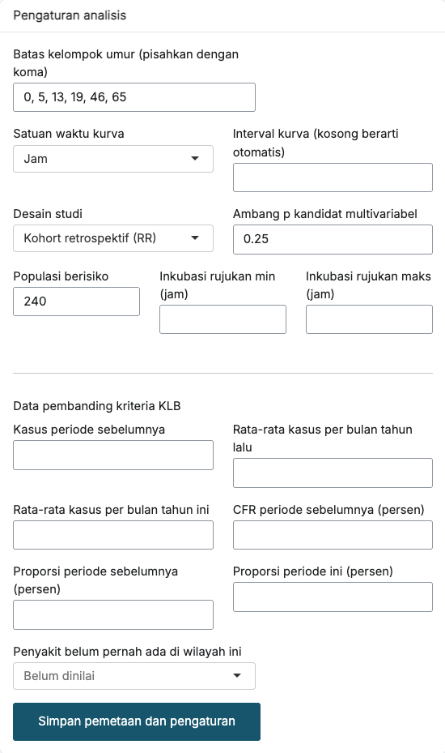

Pengaturan analisis dan data pembanding kriteria KLB

| Isian | Bawaan | Kapan diubah |
| --- | --- | --- |
| Batas kelompok umur | 0, 5, 13, 19, 46, 65 | Sesuaikan dengan kelompok umur yang lazim pada penyakit tersebut |
| Satuan waktu kurva | Jam | Hari atau minggu untuk KLB yang berlangsung lama |
| Interval kurva | otomatis | Kosongkan agar memakai seperempat masa inkubasi rata-rata sesuai pedoman |
| Desain studi | Kohort | Pilih kasus kontrol bila kontrol dipilih terpisah, hasilnya menjadi OR |
| Ambang p kandidat multivariabel | 0,25 | Lazim dipakai pada investigasi KLB |
| Populasi berisiko | kosong | Isi bila jumlah terpapar diperkirakan lebih besar daripada yang berhasil diwawancarai |
| Masa inkubasi rujukan | kosong | Isi bila masa inkubasi penyakit sudah diketahui, dipakai untuk periode paparan dan bentuk kurva |

Bagian **data pembanding** diisi dari data surveilans rutin, dan dipakai menilai kriteria KLB huruf b sampai g.

Terakhir, klik **Simpan pemetaan dan pengaturan**.

# 7 Menjalankan analisis

Buka tab **Analisis** lalu klik **Jalankan analisis**. Perhitungan berjalan di komputer Anda dan biasanya selesai dalam hitungan detik.

## 7.1 Ringkasan

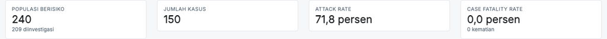

Ringkasan hasil analisis

Attack rate dihitung dengan penyebut jumlah responden yang berhasil diinvestigasi. Bila Anda mengisi populasi berisiko yang lebih besar, angka itu dilaporkan terpisah dan aplikasi mencantumkan catatan.

## 7.2 Distribusi gejala dan kelompok umur

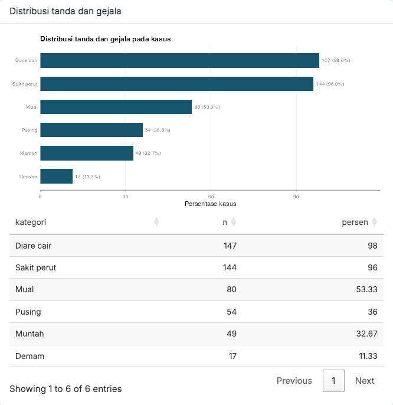

Distribusi tanda dan gejala pada kasus

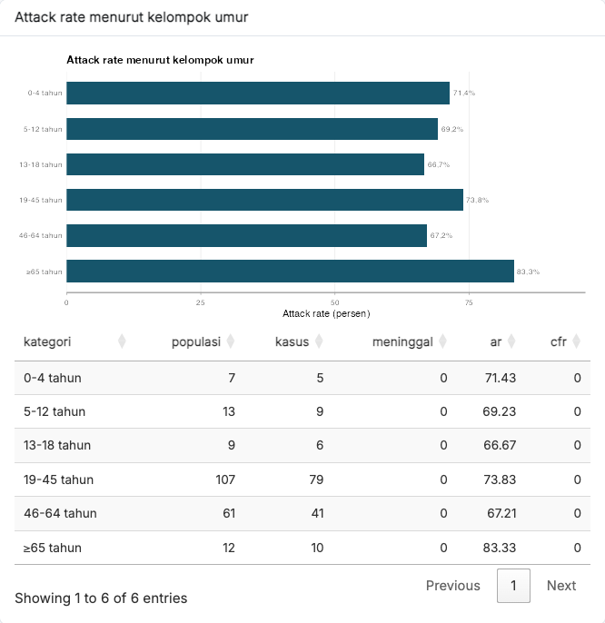

Attack rate menurut kelompok umur

Perhatikan perbedaan penting: jumlah kasus terbanyak belum tentu berada pada kelompok dengan attack rate tertinggi. Kesimpulan kelompok berisiko harus memakai attack rate, bukan jumlah kasus.

## 7.3 Kurva epidemik

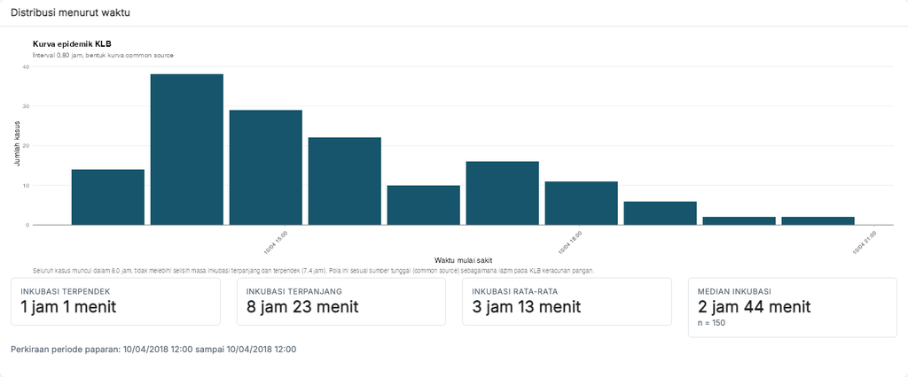

Kurva epidemik beserta ringkasan masa inkubasi

Interval kurva mengikuti seperempat masa inkubasi rata-rata sesuai Pedoman KLB 2020. Aplikasi juga menilai bentuk kurva:

- **Common source** bila seluruh kasus muncul dalam rentang yang tidak melebihi selisih masa inkubasi terpanjang dan terpendek.
- **Propagated source** bila periode KLB melampaui rentang itu, atau kurva menunjukkan lebih dari satu puncak.

Alasan penilaian ditulis di bawah gambar agar dapat Anda tinjau ulang.

## 7.4 Analisis paparan

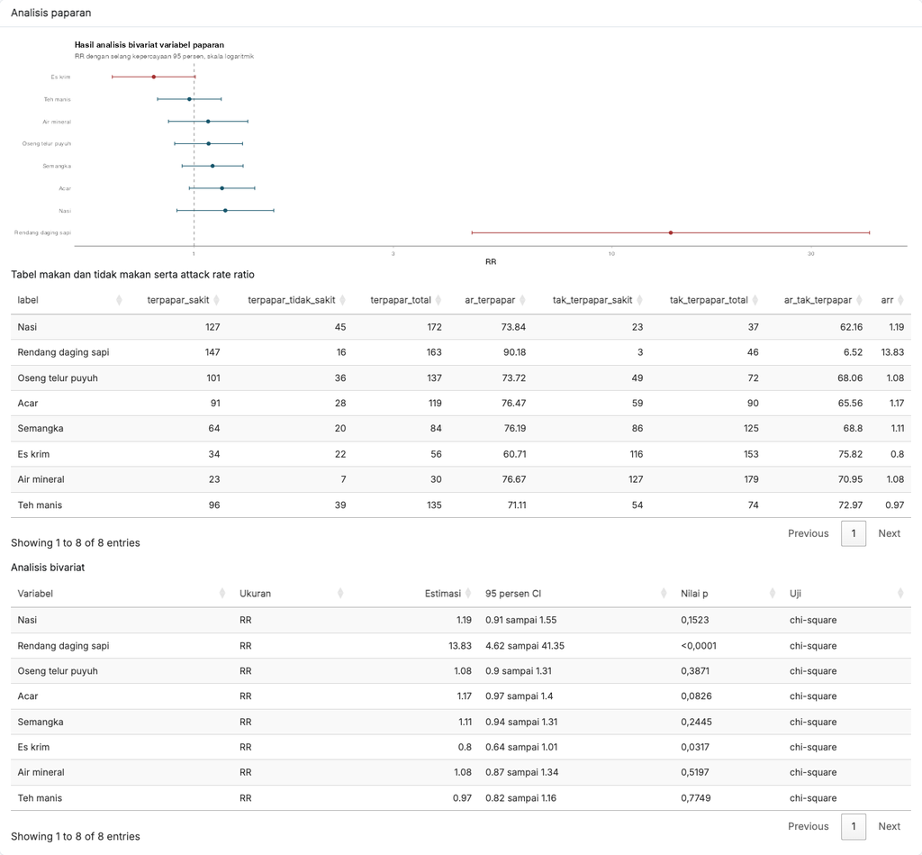

Tabel paparan, grafik, dan analisis bivariat

Tabel pertama menyajikan jumlah sakit dan tidak sakit pada kelompok terpapar dan tidak terpapar, attack rate keduanya, serta attack rate ratio. Tabel kedua menyajikan RR atau OR dengan selang kepercayaan 95 persen dan nilai p. Uji chi-square dipakai bila seluruh frekuensi harapan minimal lima, selain itu dipakai uji Fisher exact.

## 7.5 Analisis multivariabel

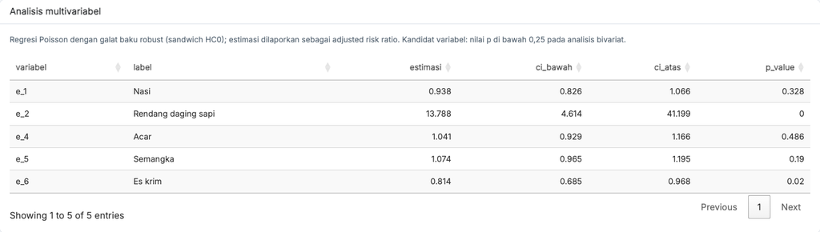

Hasil model multivariabel

Variabel dengan nilai p di bawah ambang masuk ke model. Desain kohort memakai regresi Poisson dengan galat baku robust sehingga menghasilkan adjusted risk ratio, sedangkan desain kasus kontrol memakai regresi logistik dan menghasilkan adjusted odds ratio.

## 7.6 Diagnosis banding etiologi

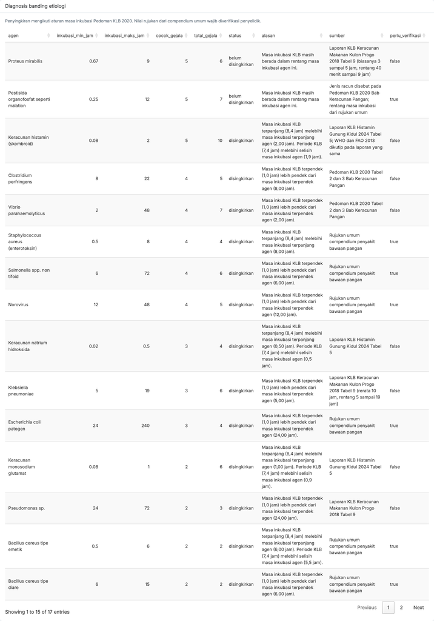

Tabel diagnosis banding

Penyingkiran agen mengikuti tiga aturan Pedoman KLB 2020, dan alasannya ditulis pada tiap baris.

**PentingNilai rujukan wajib diverifikasi**

Sebagian nilai masa inkubasi berasal dari compendium umum, bukan dari dokumen pedoman. Baris tersebut ditandai pada kolom sumber dan wajib Anda periksa terhadap pedoman yang berlaku sebelum dipakai menarik kesimpulan.

## 7.7 Penetapan KLB

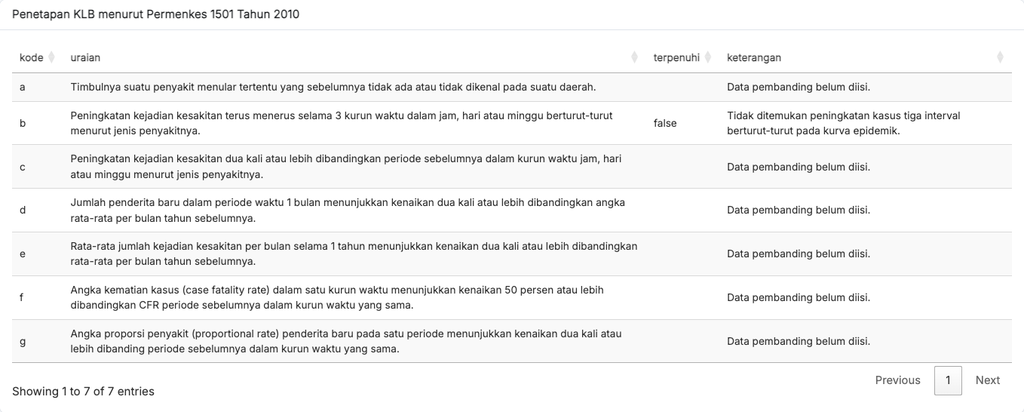

Penilaian tujuh kriteria KLB

Penilaian mengikuti tujuh kriteria Permenkes 1501 Tahun 2010. Kriteria yang memerlukan data pembanding akan berstatus belum dinilai sampai Anda mengisinya pada tab Pemetaan variabel.

```r
kr <- kriteria_klb()[, c("kode", "uraian")]
names(kr) <- c("Kode", "Kriteria KLB menurut Permenkes 1501 Tahun 2010")
knitr::kable(kr)
```

| Kode | Kriteria KLB menurut Permenkes 1501 Tahun 2010 |
| --- | --- |
| a | Timbulnya suatu penyakit menular tertentu yang sebelumnya tidak ada atau tidak dikenal pada suatu daerah. |
| b | Peningkatan kejadian kesakitan terus menerus selama 3 kurun waktu dalam jam, hari atau minggu berturut-turut menurut jenis penyakitnya. |
| c | Peningkatan kejadian kesakitan dua kali atau lebih dibandingkan periode sebelumnya dalam kurun waktu jam, hari atau minggu menurut jenis penyakitnya. |
| d | Jumlah penderita baru dalam periode waktu 1 bulan menunjukkan kenaikan dua kali atau lebih dibandingkan angka rata-rata per bulan tahun sebelumnya. |
| e | Rata-rata jumlah kejadian kesakitan per bulan selama 1 tahun menunjukkan kenaikan dua kali atau lebih dibandingkan rata-rata per bulan tahun sebelumnya. |
| f | Angka kematian kasus (case fatality rate) dalam satu kurun waktu menunjukkan kenaikan 50 persen atau lebih dibandingkan CFR periode sebelumnya dalam kurun waktu yang sama. |
| g | Angka proporsi penyakit (proportional rate) penderita baru pada satu periode menunjukkan kenaikan dua kali atau lebih dibanding periode sebelumnya dalam kurun waktu yang sama. |

## 7.8 Sebaran kasus

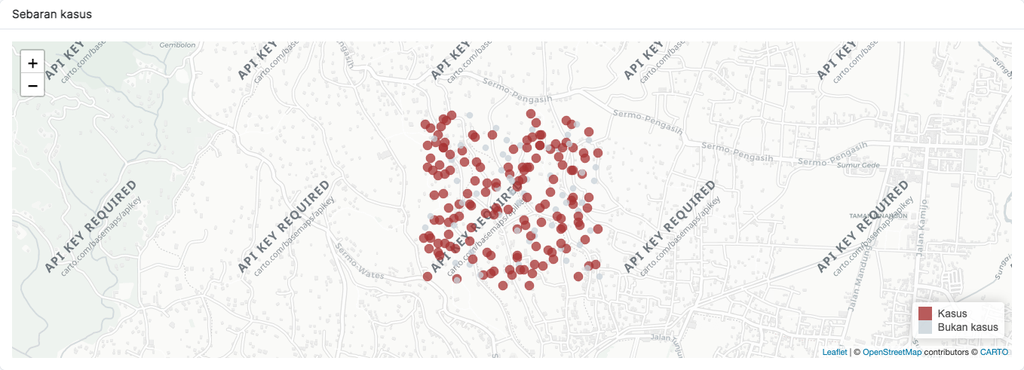

Spot map sebaran kasus

Peta muncul bila koordinat responden dipetakan. Titik merah menandai kasus, titik abu menandai bukan kasus.

# 8 Menyusun laporan

Buka tab **Laporan**. Susunan bab mengikuti Panduan Penulisan Laporan KLB dengan format IMRAD.

## 8.1 Mengisi metadata

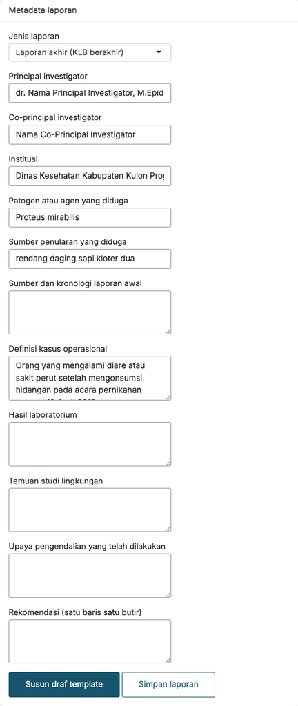

Metadata laporan

Isian pada bagian ini melengkapi hal hal yang tidak dapat dihitung dari data, misalnya kronologi awal, definisi kasus operasional, hasil laboratorium, dan temuan studi lingkungan.

Setelah terisi, klik **Susun draf template**. Aplikasi menyusun naskah lengkap seluruh bab, dan **seluruh angkanya diambil langsung dari hasil analisis**.

## 8.2 Menyunting naskah

[figure not shown]

Penyunting naskah laporan

Pilih bab pada daftar, lalu sunting isinya. Tombol **Kembalikan draf template** mengembalikan bab tersebut ke versi hasil perhitungan bila Anda ingin mengulang.

## 8.3 Memakai model bahasa

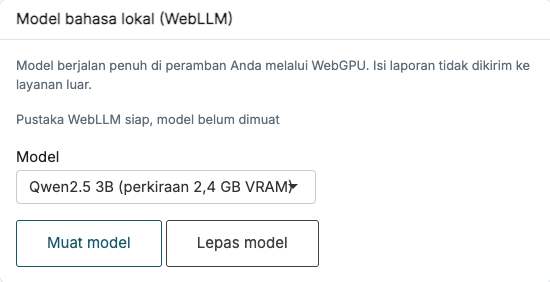

Panel model bahasa

Model bahasa berjalan **penuh di peramban Anda** melalui WebGPU, sehingga isi laporan tidak dikirim ke layanan mana pun. Cara memakainya:

1. Pilih model. Mulailah dari Llama 3.2 1B yang paling ringan bila jaringan Anda lambat.
2. Klik **Muat model**. Unduhan pertama berkisar 0,9 sampai 2,5 GB dan hanya sekali per peramban, karena tersimpan pada cache.
3. Pilih bab yang ingin diperhalus, lalu klik **Tulis bagian ini dengan WebLLM**.

Model hanya menyusun narasi. Seluruh angka dikirim kepadanya sebagai daftar fakta, disertai larangan menambah angka maupun sitasi. Setelah model selesai menulis, aplikasi memeriksa naskahnya secara otomatis terhadap dua risiko, yaitu angka yang tidak ada pada hasil analisis, dan kalimat yang menyatakan kepastian penyebab.

**PeringatanNaskah model tetap harus diperiksa**

Model kecil masih dapat salah menyalin angka atau menulis kalimat spekulatif. Bandingkan naskah dengan tabel analisis sebelum laporan dipakai. Bila peramban Anda tidak mendukung WebGPU, draf template tetap tersedia dan sudah memuat seluruh angka.

## 8.4 Memantau kelengkapan

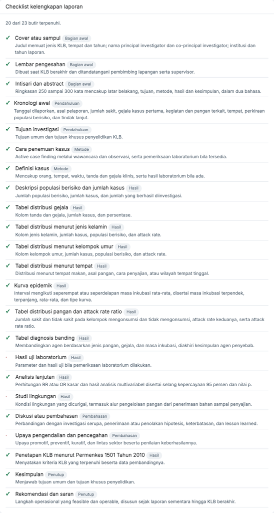

Checklist kelengkapan laporan

Checklist disusun dari Checklist Laporan KLB Keracunan Makanan dan Panduan Penulisan Laporan KLB. Butir yang sudah terpenuhi ditandai centang, dan daftarnya menyesuaikan jenis laporan, sementara atau akhir.

## 8.5 Mengekspor laporan

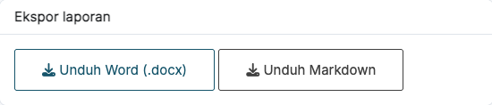

Tombol ekspor laporan

Berkas Word berisi seluruh bab, tabel bernomor, kurva epidemik, grafik attack rate, dan grafik hasil analisis paparan. Berkas Markdown berguna bila Anda ingin melanjutkan penulisan di Quarto.